# Qyestion 3

Adam Uziel, Amir Zehavi and Itay Asraf

6/4/2021

# Question 3:

### Intro:

- The meaningful question: how can the changes in US public support (separated by countries) in Donald Trump explain the extent of the damage from covid-19 (that those countries have experienced)?
- We will look for 2 interesting explorations.
  1. how can the public support in Trump during elections polls explain covid cases and deaths?
  2. how can the changes in public support in Trump (per State) between 2016 elections and 2020 elections can explain the damage those states experienced from the virus.

**First, lets import the needed libraries.**

```r
library("tidyverse")
library(rvest)
library(lubridate)
library(here)
library(glue)
library(data.table)
library(readr)
library(tidymodels)
```

- We would start with `deaths_us` and `cases_us` data-sets from question 1.

```r
deaths_us <- read_csv(here::here("data", "Death_US_final.csv"))
cases_us <- read_csv(here::here("data", "Cases_US_final.csv"))
deaths_us
```

```
## # A tibble: 25,575 x 5
##    State num_deaths area  Date       full_name
##    <chr>      <dbl> <chr> <date>     <chr>
##  1 AK             0 West  2020-02-29 Alaska
##  2 AZ             0 West  2020-02-29 Arizona
##  3 CA             0 West  2020-02-29 California
##  4 CO             0 West  2020-02-29 Colorado
##  5 HI             0 West  2020-02-29 Hawaii
##  6 ID             0 West  2020-02-29 Idaho
##  7 MT             0 West  2020-02-29 Montana
##  8 NM             0 West  2020-02-29 New Mexico
##  9 NV             0 West  2020-02-29 Nevada
## 10 OR             0 West  2020-02-29 Oregon
## # ... with 25,565 more rows
```

```r
cases_us
```

```
## # A tibble: 26,400 x 4
##    State num_cases area  Date
##    <chr>     <dbl> <chr> <date>
##  1 AK            0 West  2020-01-21
##  2 AZ            0 West  2020-01-21
##  3 CA            0 West  2020-01-21
##  4 CO            0 West  2020-01-21
##  5 HI            0 West  2020-01-21
##  6 ID            0 West  2020-01-21
##  7 MT            0 West  2020-01-21
##  8 NM            0 West  2020-01-21
##  9 NV            0 West  2020-01-21
## 10 OR            0 West  2020-01-21
## # ... with 26,390 more rows
```

```r
deaths_us <- deaths_us %>%
  rename(short_name = State)
cases_us <- cases_us %>% rename(short_name = State)
deaths_us
```

```
## # A tibble: 25,575 x 5
##    short_name num_deaths area  Date       full_name
##    <chr>           <dbl> <chr> <date>     <chr>
##  1 AK                  0 West  2020-02-29 Alaska
##  2 AZ                  0 West  2020-02-29 Arizona
##  3 CA                  0 West  2020-02-29 California
##  4 CO                  0 West  2020-02-29 Colorado
##  5 HI                  0 West  2020-02-29 Hawaii
##  6 ID                  0 West  2020-02-29 Idaho
##  7 MT                  0 West  2020-02-29 Montana
##  8 NM                  0 West  2020-02-29 New Mexico
##  9 NV                  0 West  2020-02-29 Nevada
## 10 OR                  0 West  2020-02-29 Oregon
## # ... with 25,565 more rows
```

```r
cases_us
```

```
## # A tibble: 26,400 x 4
##    short_name num_cases area  Date
##    <chr>          <dbl> <chr> <date>
##  1 AK                 0 West  2020-01-21
##  2 AZ                 0 West  2020-01-21
##  3 CA                 0 West  2020-01-21
##  4 CO                 0 West  2020-01-21
##  5 HI                 0 West  2020-01-21
##  6 ID                 0 West  2020-01-21
##  7 MT                 0 West  2020-01-21
##  8 NM                 0 West  2020-01-21
##  9 NV                 0 West  2020-01-21
## 10 OR                 0 West  2020-01-21
## # ... with 26,390 more rows
```

Let’s take a look on the variables:

```r
glimpse(deaths_us)
```

```
## Rows: 25,575
## Columns: 5
## $ short_name <chr> "AK", "AZ", "CA", "CO", "HI", "ID", "MT", "NM", "NV", "OR",~
## $ num_deaths <dbl> 0, 0, 0, 0, 0, 0, 0, 0, 0, 0, 0, 1, 0, 0, 0, 0, 0, 0, 0, 0,~
## $ area       <chr> "West", "West", "West", "West", "West", "West", "West", "We~
## $ Date       <date> 2020-02-29, 2020-02-29, 2020-02-29, 2020-02-29, 2020-02-29~
## $ full_name  <chr> "Alaska", "Arizona", "California", "Colorado", "Hawaii", "I~
```

- Let’s find all the relevant states with their *`full_name`* and *`short_name`* values.

```r
countries <- deaths_us %>%
  select(short_name, full_name, area) %>%
  distinct() %>%
  mutate(full_name = if_else(short_name=="DC","District of Columbia", full_name )) %>%
  filter(!is.na(full_name))
countries
```

```
## # A tibble: 51 x 3
##    short_name full_name  area
##    <chr>      <chr>      <chr>
##  1 AK         Alaska     West
##  2 AZ         Arizona    West
##  3 CA         California West
##  4 CO         Colorado   West
##  5 HI         Hawaii     West
##  6 ID         Idaho      West
##  7 MT         Montana    West
##  8 NM         New Mexico West
##  9 NV         Nevada     West
## 10 OR         Oregon     West
## # ... with 41 more rows
```

- Merging the tables to one data-set:

```r
merged_covid_wiki <- cases_us %>%
  left_join(deaths_us) %>%
  mutate(num_deaths = replace_na(num_deaths,0)) %>%
  select(short_name, num_cases, Date, num_deaths) %>%
  left_join(countries)
merged_covid_wiki
```

```
## # A tibble: 26,400 x 6
##    short_name num_cases Date       num_deaths full_name  area
##    <chr>          <dbl> <date>          <dbl> <chr>      <chr>
##  1 AK                 0 2020-01-21          0 Alaska     West
##  2 AZ                 0 2020-01-21          0 Arizona    West
##  3 CA                 0 2020-01-21          0 California West
##  4 CO                 0 2020-01-21          0 Colorado   West
##  5 HI                 0 2020-01-21          0 Hawaii     West
##  6 ID                 0 2020-01-21          0 Idaho      West
##  7 MT                 0 2020-01-21          0 Montana    West
##  8 NM                 0 2020-01-21          0 New Mexico West
##  9 NV                 0 2020-01-21          0 Nevada     West
## 10 OR                 0 2020-01-21          0 Oregon     West
## # ... with 26,390 more rows
```

- Minimum and Maximum dates.
- It’s relevant for the elections polls data-set.
- We will use those date in order to filter the dates of the polls.

```r
min_date <- min(merged_covid_wiki$Date)
max_date<- max(merged_covid_wiki$Date)
min_date
```

```
## [1] "2020-01-21"
```

```r
max_date
```

```
## [1] "2021-06-07"
```

### Exploration 1: data on election polls.

- I have found a data-set that contains some `elections polls`.
- We will see some visualizations in order to explore this collected information.
- And the most important part- We will try to answer the research question based on creating connection between the wiki cases-deaths data-sets and the polls data-set.

```r
elections_polls <- read_csv(here::here("data", "trump_biden_polls.csv")) %>%
  rename(full_name = state)
elections_polls
```

```
## # A tibble: 16,438 x 38
##    question_id poll_id cycle full_name pollster_id pollster sponsor_ids sponsors
##          <dbl>   <dbl> <dbl> <chr>           <dbl> <chr>          <dbl> <chr>
##  1      136283   72621  2020 Iowa              383 Public ~          NA <NA>
##  2      136283   72621  2020 Iowa              383 Public ~          NA <NA>
##  3      136322   72647  2020 Pennsylv~         461 Susqueh~          NA <NA>
##  4      136322   72647  2020 Pennsylv~         461 Susqueh~          NA <NA>
##  5      136322   72647  2020 Pennsylv~         461 Susqueh~          NA <NA>
##  6      136491   72722  2020 Florida           235 Opinion~         364 FOX35 O~
##  7      136491   72722  2020 Florida           235 Opinion~         364 FOX35 O~
##  8      136491   72722  2020 Florida           235 Opinion~         364 FOX35 O~
##  9      136338   72652  2020 <NA>             1478 Researc~          NA <NA>
## 10      136338   72652  2020 <NA>             1478 Researc~          NA <NA>
## # ... with 16,428 more rows, and 30 more variables: display_name <chr>,
## #   pollster_rating_id <dbl>, pollster_rating_name <chr>, fte_grade <chr>,
## #   sample_size <dbl>, population <chr>, population_full <chr>,
## #   methodology <chr>, office_type <chr>, seat_number <dbl>, seat_name <lgl>,
## #   start_date <chr>, end_date <chr>, election_date <chr>,
## #   sponsor_candidate <lgl>, internal <lgl>, partisan <chr>, tracking <lgl>,
## #   nationwide_batch <lgl>, ranked_choice_reallocated <lgl>, created_at <chr>,
## #   notes <chr>, url <chr>, stage <chr>, race_id <dbl>, answer <chr>,
## #   candidate_id <dbl>, candidate_name <chr>, candidate_party <chr>, pct <dbl>
```

Another look on the variables:

```r
glimpse(elections_polls)
```

```
## Rows: 16,438
## Columns: 38
## $ question_id               <dbl> 136283, 136283, 136322, 136322, 136322, 1364~
## $ poll_id                   <dbl> 72621, 72621, 72647, 72647, 72647, 72722, 72~
## $ cycle                     <dbl> 2020, 2020, 2020, 2020, 2020, 2020, 2020, 20~
## $ full_name                 <chr> "Iowa", "Iowa", "Pennsylvania", "Pennsylvani~
## $ pollster_id               <dbl> 383, 383, 461, 461, 461, 235, 235, 235, 1478~
## $ pollster                  <chr> "Public Policy Polling", "Public Policy Poll~
## $ sponsor_ids               <dbl> NA, NA, NA, NA, NA, 364, 364, 364, NA, NA, N~
## $ sponsors                  <chr> NA, NA, NA, NA, NA, "FOX35 Orlando", "FOX35 ~
## $ display_name              <chr> "Public Policy Polling", "Public Policy Poll~
## $ pollster_rating_id        <dbl> 263, 263, 326, 326, 326, 243, 243, 243, 449,~
## $ pollster_rating_name      <chr> "Public Policy Polling", "Public Policy Poll~
## $ fte_grade                 <chr> "B", "B", "C", "C", "C", "B-", "B-", "B-", "~
## $ sample_size               <dbl> 871, 871, 499, 499, 499, 400, 400, 400, 1025~
```

[output cut: 25 more lines]

- Some tidying: making `start_date` & `end_date` variables in the needed format for our analysis.

```r
elections_polls <-  elections_polls %>%
  separate(start_date, into = c("Month1", "Day1", "Year1"), sep = "/") %>%
  separate(end_date, into= c("Month2", "Day2", "Year2"), sep = "/")
elections_polls$Day1 = as.numeric(elections_polls$Day1)
elections_polls$Month1 = as.numeric(elections_polls$Month1)
elections_polls$Year1 = as.numeric(elections_polls$Year1)
elections_polls$Day2 = as.numeric(elections_polls$Day2)
elections_polls$Month2 = as.numeric(elections_polls$Month2)
elections_polls$Year2 = as.numeric(elections_polls$Year2)


elections_polls <- elections_polls %>%
  mutate(Year1 = case_when(
    Year1==20 ~ 2020,
    Year1==19 ~ 2019,
    Year1==18 ~2018,
    T ~ Year1
  ),
  Year2 = case_when(
    Year2==20 ~ 2020,
    Year2==19 ~ 2019,
    Year2==18 ~2018,
    T ~ Year2
  ))
elections_polls$start_date = as.Date(with(elections_polls, paste(Year1,Month1,Day1, sep = "-")), "%Y-%m-%d")

elections_polls$end_date = as.Date(with(elections_polls, paste(Year2,Month2,Day2, sep = "-")), "%Y-%m-%d")

elections_polls <-elections_polls %>% select(-Month1, -Month2, -Year1, -Year2, -Day1, -Day2)
elections_polls
```

```
## # A tibble: 16,438 x 38
##    question_id poll_id cycle full_name pollster_id pollster sponsor_ids sponsors
##          <dbl>   <dbl> <dbl> <chr>           <dbl> <chr>          <dbl> <chr>
##  1      136283   72621  2020 Iowa              383 Public ~          NA <NA>
##  2      136283   72621  2020 Iowa              383 Public ~          NA <NA>
##  3      136322   72647  2020 Pennsylv~         461 Susqueh~          NA <NA>
##  4      136322   72647  2020 Pennsylv~         461 Susqueh~          NA <NA>
##  5      136322   72647  2020 Pennsylv~         461 Susqueh~          NA <NA>
##  6      136491   72722  2020 Florida           235 Opinion~         364 FOX35 O~
##  7      136491   72722  2020 Florida           235 Opinion~         364 FOX35 O~
##  8      136491   72722  2020 Florida           235 Opinion~         364 FOX35 O~
##  9      136338   72652  2020 <NA>             1478 Researc~          NA <NA>
## 10      136338   72652  2020 <NA>             1478 Researc~          NA <NA>
## # ... with 16,428 more rows, and 30 more variables: display_name <chr>,
## #   pollster_rating_id <dbl>, pollster_rating_name <chr>, fte_grade <chr>,
## #   sample_size <dbl>, population <chr>, population_full <chr>,
## #   methodology <chr>, office_type <chr>, seat_number <dbl>, seat_name <lgl>,
## #   election_date <chr>, sponsor_candidate <lgl>, internal <lgl>,
## #   partisan <chr>, tracking <lgl>, nationwide_batch <lgl>,
## #   ranked_choice_reallocated <lgl>, created_at <chr>, notes <chr>, url <chr>,
## #   stage <chr>, race_id <dbl>, answer <chr>, candidate_id <dbl>,
## #   candidate_name <chr>, candidate_party <chr>, pct <dbl>, start_date <date>,
## #   end_date <date>
```

- Changes in some of the States `full_name` values .

```r
elections_polls <- elections_polls %>%
  filter(!is.na(full_name)) %>%
  mutate(full_name = case_when(
    full_name=="Nebraska CD-2" ~ "Nebraska",
    full_name=="Maine CD-2" ~ "Maine",
    full_name=="Maine CD-1" ~ "Maine",
    full_name=="Nebraska CD-1" ~ "Nebraska",
    T ~ full_name
  )) %>%
  left_join(countries)
elections_polls
```

```
## # A tibble: 11,385 x 40
##    question_id poll_id cycle full_name pollster_id pollster sponsor_ids sponsors
##          <dbl>   <dbl> <dbl> <chr>           <dbl> <chr>          <dbl> <chr>
##  1      136283   72621  2020 Iowa              383 Public ~          NA <NA>
##  2      136283   72621  2020 Iowa              383 Public ~          NA <NA>
##  3      136322   72647  2020 Pennsylv~         461 Susqueh~          NA <NA>
##  4      136322   72647  2020 Pennsylv~         461 Susqueh~          NA <NA>
##  5      136322   72647  2020 Pennsylv~         461 Susqueh~          NA <NA>
##  6      136491   72722  2020 Florida           235 Opinion~         364 FOX35 O~
##  7      136491   72722  2020 Florida           235 Opinion~         364 FOX35 O~
##  8      136491   72722  2020 Florida           235 Opinion~         364 FOX35 O~
##  9      136533   72754  2020 Nebraska         1613 Univers~          NA <NA>
## 10      136533   72754  2020 Nebraska         1613 Univers~          NA <NA>
## # ... with 11,375 more rows, and 32 more variables: display_name <chr>,
## #   pollster_rating_id <dbl>, pollster_rating_name <chr>, fte_grade <chr>,
## #   sample_size <dbl>, population <chr>, population_full <chr>,
## #   methodology <chr>, office_type <chr>, seat_number <dbl>, seat_name <lgl>,
## #   election_date <chr>, sponsor_candidate <lgl>, internal <lgl>,
## #   partisan <chr>, tracking <lgl>, nationwide_batch <lgl>,
## #   ranked_choice_reallocated <lgl>, created_at <chr>, notes <chr>, url <chr>,
## #   stage <chr>, race_id <dbl>, answer <chr>, candidate_id <dbl>,
## #   candidate_name <chr>, candidate_party <chr>, pct <dbl>, start_date <date>,
## #   end_date <date>, short_name <chr>, area <chr>
```

- Matching the dates here to the dates in the `merged_covid_wiki` data-set.
- Calculation of the difference between `end_date` and `start_date`

```r
elections_polls <- elections_polls %>% filter(start_date<=max_date & start_date>=min_date & end_date<=max_date & end_date>=min_date) %>%
  mutate(diff = end_date-start_date,
         diff = as.numeric(diff))
elections_polls
```

```
## # A tibble: 9,808 x 41
##    question_id poll_id cycle full_name pollster_id pollster sponsor_ids sponsors
##          <dbl>   <dbl> <dbl> <chr>           <dbl> <chr>          <dbl> <chr>
##  1      136283   72621  2020 Iowa              383 Public ~          NA <NA>
##  2      136283   72621  2020 Iowa              383 Public ~          NA <NA>
##  3      136322   72647  2020 Pennsylv~         461 Susqueh~          NA <NA>
##  4      136322   72647  2020 Pennsylv~         461 Susqueh~          NA <NA>
##  5      136322   72647  2020 Pennsylv~         461 Susqueh~          NA <NA>
##  6      136491   72722  2020 Florida           235 Opinion~         364 FOX35 O~
##  7      136491   72722  2020 Florida           235 Opinion~         364 FOX35 O~
##  8      136491   72722  2020 Florida           235 Opinion~         364 FOX35 O~
##  9      136533   72754  2020 Nebraska         1613 Univers~          NA <NA>
## 10      136533   72754  2020 Nebraska         1613 Univers~          NA <NA>
## # ... with 9,798 more rows, and 33 more variables: display_name <chr>,
## #   pollster_rating_id <dbl>, pollster_rating_name <chr>, fte_grade <chr>,
## #   sample_size <dbl>, population <chr>, population_full <chr>,
## #   methodology <chr>, office_type <chr>, seat_number <dbl>, seat_name <lgl>,
## #   election_date <chr>, sponsor_candidate <lgl>, internal <lgl>,
## #   partisan <chr>, tracking <lgl>, nationwide_batch <lgl>,
## #   ranked_choice_reallocated <lgl>, created_at <chr>, notes <chr>, url <chr>,
## #   stage <chr>, race_id <dbl>, answer <chr>, candidate_id <dbl>,
## #   candidate_name <chr>, candidate_party <chr>, pct <dbl>, start_date <date>,
## #   end_date <date>, short_name <chr>, area <chr>, diff <dbl>
```

- Finding the 10 most popular States in the `elections_polls` data-set.

```r
most_popular_states<- elections_polls %>%
  count(full_name, sort = T) %>%
  head(10)
most_popular_states
```

```
## # A tibble: 10 x 2
##    full_name          n
##    <chr>          <int>
##  1 Wisconsin        739
##  2 Pennsylvania     570
##  3 North Carolina   550
##  4 Michigan         534
##  5 Florida          494
##  6 Arizona          442
##  7 Texas            343
##  8 Georgia          299
##  9 Maine            265
## 10 Ohio             235
```

### Plot 1

- Among those States: visualization of Frequency of polls that the candidates won.

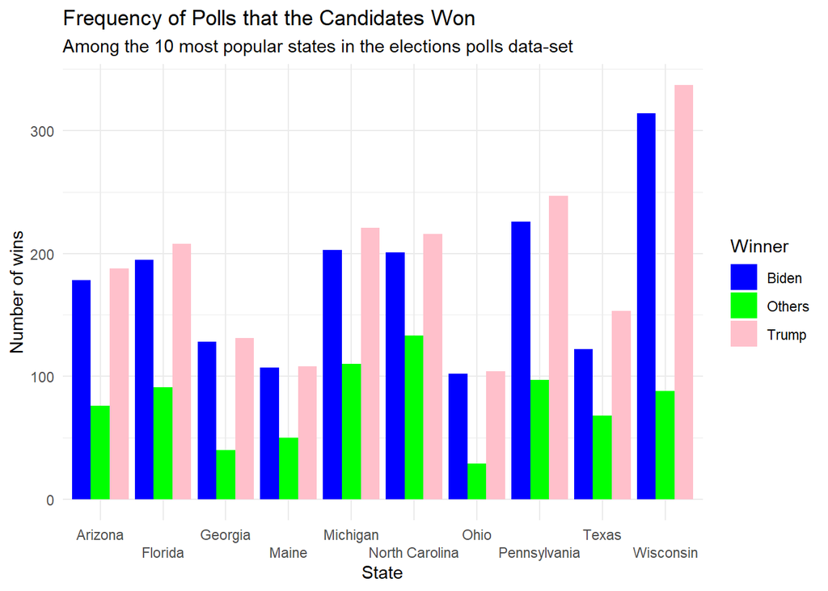

```r
temp_gg_1<- elections_polls %>%
  filter(full_name %in% most_popular_states$full_name) %>%
  mutate(answer = case_when(
    answer=="Biden" ~ "Biden",
    answer=="Trump" ~ "Trump",
    T ~ "Others"
  ))
ggplot(data = temp_gg_1,mapping = aes(x = factor(full_name) , fill = answer) ) +
  geom_bar(stat = "count", position = "dodge") +
  scale_x_discrete(guide = ggplot2::guide_axis(n.dodge = 2),
                   labels = function(x) stringr::str_wrap(x, width = 20)) +
  scale_fill_manual(values = c("blue", "green", "pink") ,
                    name = "Winner")+
  labs(
    x = "State",
    y = "Number of wins",
    title = "Frequency of Polls that the Candidates Won",
    subtitle = "Among the 10 most popular states in the elections polls data-set"
  ) +
  theme_minimal()
```

```r
#ggsave("Frequency of Polls that the Candidates Won.png")
```

**Explanation:**

- We can see that Trump have won more polls than Biden.
- Maybe some of the polls occur before Biden selected to the democrat’s candidate.
- There are more polls of Trump’s loss than polls of him wining.

### Plot 2

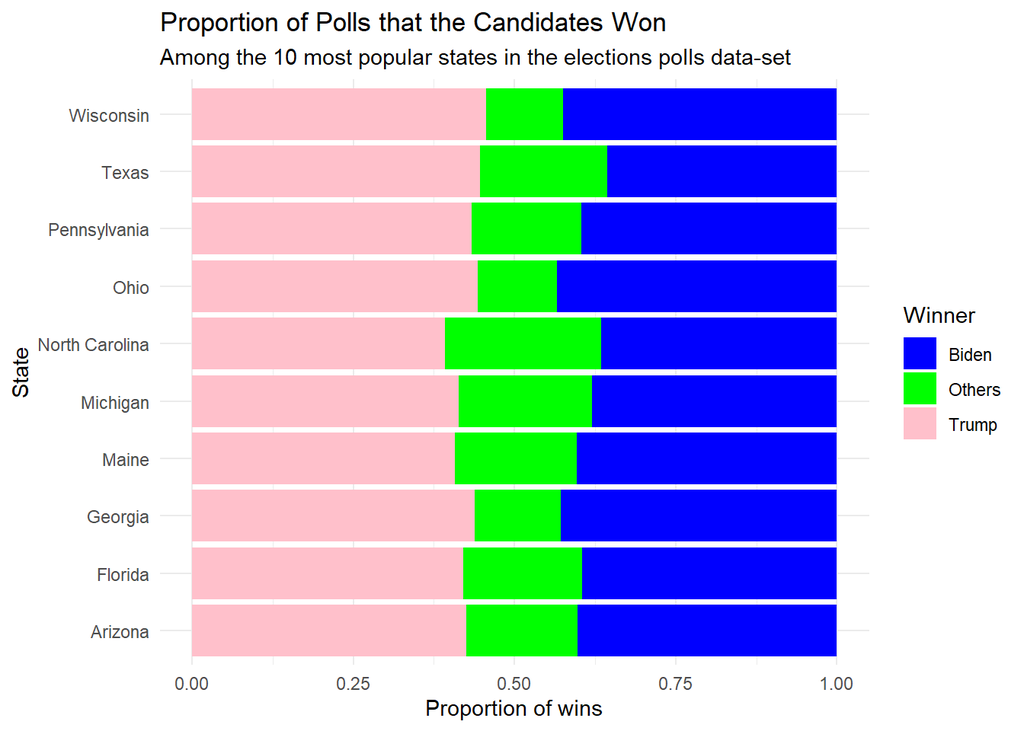

```r
ggplot(data = temp_gg_1,mapping = aes(x = factor(full_name) , fill = answer) ) +
  geom_bar(stat = "count", position = "fill") +
  scale_fill_manual(values = c("blue", "green", "pink") ,
                    name = "Winner")+
  labs(
    x = "State",
    y = "Proportion of wins",
    title = "Proportion of Polls that the Candidates Won",
    subtitle = "Among the 10 most popular states in the elections polls data-set"
  )+
  coord_flip() +
  theme_minimal()
```

```r
#ggsave("Proportion of Polls that the Candidates Won.png")
```

**Explanation:**

- Same as the last plot but with proportion instead of Count.

### Plot 3:

- Selecting the 2 most popular methodologies.
- Counting the number of votes for each party.
- Separated by the two methodologies.

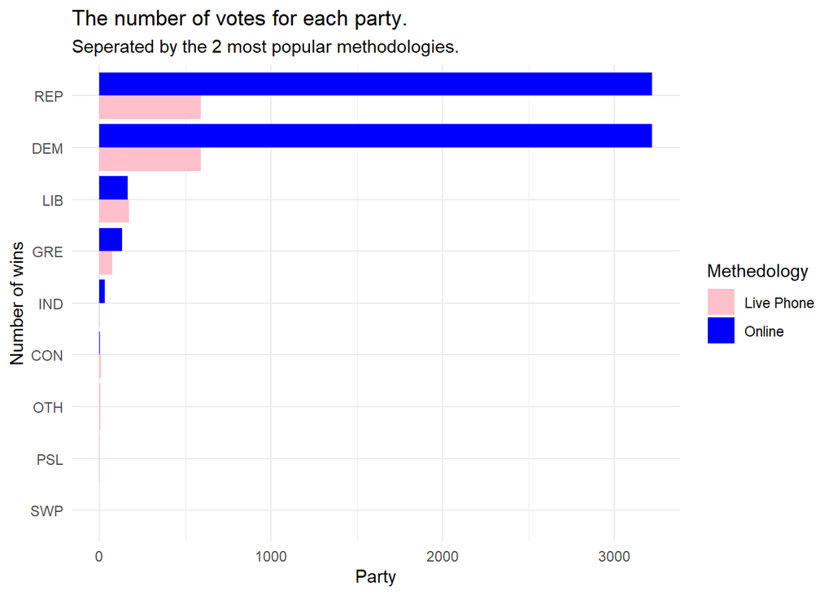

```r
popular_metho<- elections_polls %>%
  count(methodology, sort = T) %>%
  head(2)

temp_gg2 <- elections_polls %>%
  filter(methodology %in% popular_metho$methodology)

count_occur <- temp_gg2 %>%
  group_by(candidate_party) %>%
  mutate(num_parties = n())
ggplot(data = count_occur, mapping = aes(x =reorder((factor(candidate_party)), num_parties) , fill = methodology)) +
  geom_bar(stat = "count", position = "dodge")  +
  coord_flip() +
  labs(
    x = "Number of wins",
    y = "Party",
    title = "The number of votes for each party.",
    subtitle = "Seperated by the 2 most popular methodologies."
  ) +
  scale_fill_manual(values = c("pink", "blue"), name  = "Methedology") +
  theme_minimal()
```

```r
#ggsave("The number of votes for each party.png")
```

*Explanation:*

We can see that the results of the polls are nearly the same between the parties.

### Plot 4:

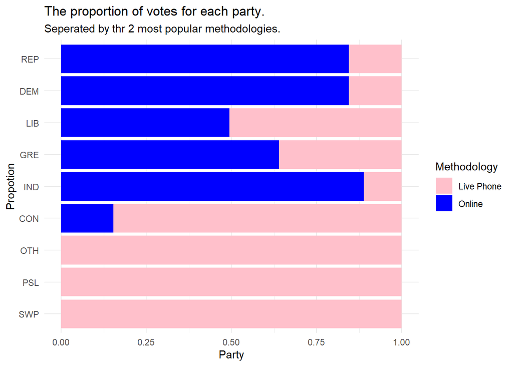

```r
ggplot(data = count_occur, mapping = aes(x =reorder((factor(candidate_party)), num_parties) , fill = methodology)) +
  geom_bar(stat = "count", position = "fill")  +
  coord_flip() +
  labs(
    x = "Propotion",
    y = "Party",
    title = "The proportion of votes for each party.",
    subtitle = "Seperated by thr 2 most popular methodologies."
  ) +
  scale_fill_manual(values = c("pink", "blue"), name = "Methodology") +
  theme_minimal()
```

```r
#ggsave("The proportion of votes for each party.png")
```

We can see the same result when we look at the proportions.

### Plot 5:

- Now, we will begin to use visualizations that will attempt to answer our research question (and not only for data exploration).
- Let’s find the 5 months with the biggest amount of covid deaths and cacses.

```r
merged_covid_wiki %>%
    mutate(cases_deaths = num_cases + num_deaths,
      year= year(Date),
         month =month(Date)
         ) %>%
  group_by(year, month) %>%
  summarise(sum_cases_deaths = sum(cases_deaths, na.rm = T)) %>%
  arrange(desc(sum_cases_deaths)) %>%
  head(5)
```

```
## # A tibble: 5 x 3
## # Groups:   year [2]
##    year month sum_cases_deaths
##   <int> <int>            <dbl>
## 1  2020     8           494975
## 2  2020     9           488855
## 3  2020    10           457783
## 4  2020     7           447026
## 5  2021     3           443549
```

- Among these months- we will count the number of Trump’s wins against the number of wins of all the other candidates together.

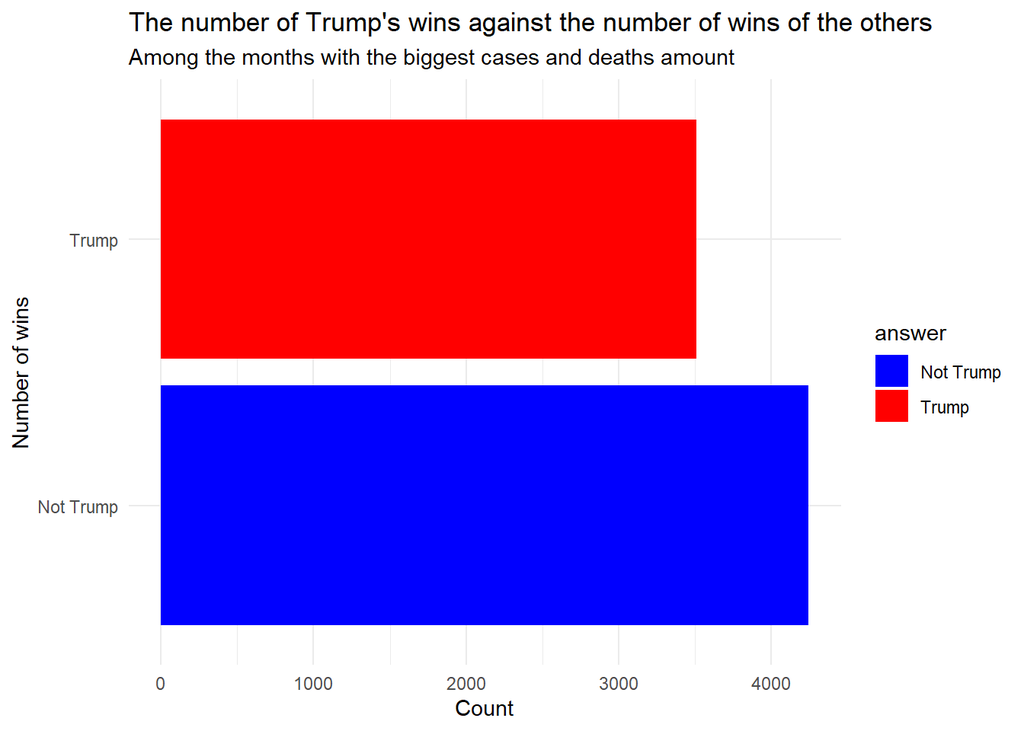

```r
temp_gg3<- elections_polls %>%
  filter(
    ((year(start_date)==2021 & month(start_date)==3)|(year(start_date)==2020 & (month(start_date) %in% c(8,9,10,7)))) & ((year(end_date)==2021 & month(end_date)==3)|(year(end_date)==2020 & (month(end_date) %in% c(8,9,10,7))))
  ) %>%
  mutate( answer = case_when(
    answer=="Trump" ~"Trump",
    T ~ "Not Trump"
  ))
ggplot(data = temp_gg3, mapping = aes(x = answer, fill = answer)) +
  geom_bar(stat = "count") +
  theme(legend.position = "none") +
  labs(
    x = NULL,
    y = "Count"
  ) +
  coord_flip() +
  scale_fill_manual(values = c("blue", "red")) +
  labs(
    x = "Number of wins",
    title = "The number of Trump's wins against the number of wins of the others",
    subtitle = "Among the months with the biggest cases and deaths amount"

  ) +
  theme_minimal()
```

```r
#ggsave("The number of Trump's wins against the number of wins of the others.png")
```

*Explanation:*

- We can see that on those months Trump has lost in most of the polls.
- does it mean that the covid cases and deaths in states can be explained by the public support in Trump?

### Creating a new data-set:

For each date among all the dates in `merged_covid_wiki`: I gave a value that represents the proportion of wins of Trumps in all polls that were occurred in that date. The is between the poll’s `start_date` and `end_date` .

```r
index<-1
Date_list <- list()
State_list <- list()
Winner_id_list <- list()
winner_name_list <- list()

for(row in 1:nrow(elections_polls)){
  curr_diff <- elections_polls[[ row,"diff"]]
  curr_start_date <- elections_polls[[ row,"start_date"]]
  Date_list[[index]] <- curr_start_date
  winner_id <- elections_polls[[ row, "candidate_id"]]
  winner_name <- elections_polls[[ row, "answer"]]
  state <- elections_polls[[ row,"full_name"]]
  Winner_id_list[[index]] <- winner_id
  winner_name_list[[index]] <- winner_name
  State_list[[index]] <- state
  while(curr_diff>0){
    curr_diff <- curr_diff - 1
    index <- index + 1
    curr_start_date <- curr_start_date + 1
    Date_list[[index]] <- curr_start_date
    State_list[[index]] <- state
    winner_name_list[[index]] <- winner_name
    Winner_id_list[[index]] <- winner_id
  }
  index <- index+1
}
```

- `new` is a temporary data-set that contain for each `Date` the results of all polls (in some State) the were occurring in this particular `Date`. the `Date` is between the poll’s `start_date` and `end_date` values.

```r
Date_vec<-do.call("c", Date_list)
State_vec <- unlist(State_list)
winner_id_vec <- unlist(Winner_id_list)
winner_name_vec <- unlist(winner_name_list)

new <- tibble(Date = Date_vec,
              full_name = State_vec,
              winner_id = winner_id_vec,
              winner_name = winner_name_vec,
              )
new
```

```
## # A tibble: 155,136 x 4
##    Date       full_name    winner_id winner_name
##    <date>     <chr>            <dbl> <chr>
##  1 2020-11-01 Iowa             13256 Biden
##  2 2020-11-02 Iowa             13256 Biden
##  3 2020-11-01 Iowa             13254 Trump
##  4 2020-11-02 Iowa             13254 Trump
##  5 2020-11-01 Pennsylvania     13256 Biden
##  6 2020-11-02 Pennsylvania     13256 Biden
##  7 2020-11-01 Pennsylvania     13254 Trump
##  8 2020-11-02 Pennsylvania     13254 Trump
##  9 2020-11-01 Pennsylvania     14611 Jorgensen
## 10 2020-11-02 Pennsylvania     14611 Jorgensen
## # ... with 155,126 more rows
```

- For each date and State: `polls_prop` contains the proportion of Trump’s wins in the polls that was occurring in those dates and states.

```r
polls_prop <- new %>%
  mutate(winner_name = if_else(winner_name=="Trump", "Trump", "Not Trump")) %>%
  count(Date, full_name, winner_name) %>%
  group_by(Date, full_name) %>%
  mutate(p = n/sum(n))
polls_prop
```

```
## # A tibble: 17,142 x 5
## # Groups:   Date, full_name [8,571]
##    Date       full_name winner_name     n     p
##    <date>     <chr>     <chr>       <int> <dbl>
##  1 2020-01-21 Texas     Not Trump       7   0.5
##  2 2020-01-21 Texas     Trump           7   0.5
##  3 2020-01-22 Arizona   Not Trump       1   0.5
##  4 2020-01-22 Arizona   Trump           1   0.5
##  5 2020-01-22 Texas     Not Trump       7   0.5
##  6 2020-01-22 Texas     Trump           7   0.5
##  7 2020-01-23 Arizona   Not Trump       1   0.5
##  8 2020-01-23 Arizona   Trump           1   0.5
##  9 2020-01-23 Texas     Not Trump       7   0.5
## 10 2020-01-23 Texas     Trump           7   0.5
## # ... with 17,132 more rows
```

### Plot 6:

- From all the pairs of date and State we would take only those that have 8 or more polls.
- Then We would calculate the average of all the proportions grouped by each month.
- We watch the distribution of the average proportions among the months that remained after the filter, separated by each `area`.

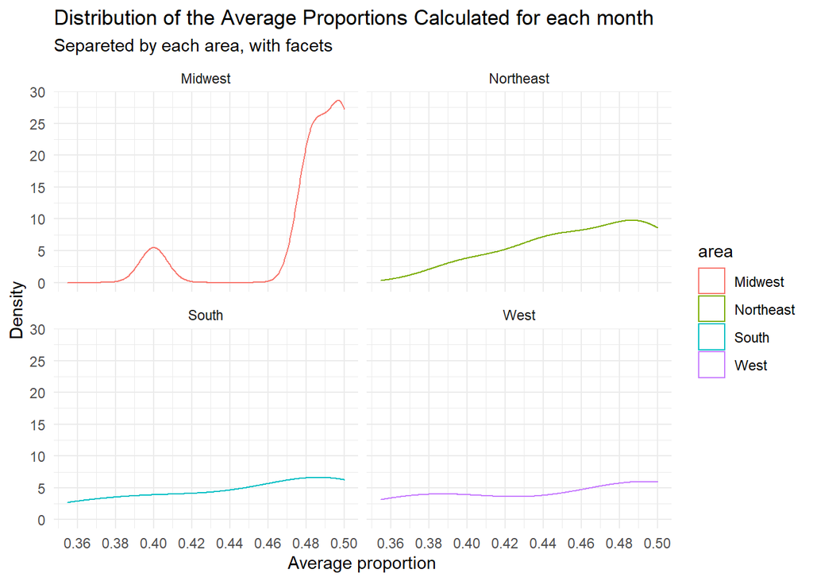

```r
temp_gg4 <- polls_prop %>%
  filter(n>=8) %>%
  left_join(countries) %>%
  filter(winner_name == "Trump") %>%
  mutate(month = month(Date),
         year = year(Date)) %>%
  group_by(year,month, area, .groups = "drop") %>%
  summarise(avg_prop = mean(p, na.rm = T))

ggplot(data = temp_gg4 , mapping = aes(x = avg_prop, color = area)) +
 geom_density() +
 facet_wrap(~ area) +
 scale_x_continuous(breaks = scales::pretty_breaks(n = 6)) +
  scale_y_continuous(breaks = scales::pretty_breaks(n = 6)) +

  labs(
    x= "Average proportion",
    y = "Density",
    title = "Distribution of the Average Proportions Calculated for each month",
    subtitle = "Separeted by each area, with facets"
  )  +
  theme_minimal()
```

```r
#ggsave("Distribution of the Average Proportions Calculated for each month.png")
```

**Explanation:**

- We can see moderate increases in the areas: West, South, Northeast. the distribution of Trump’s support is those state is nearly uniform.
- But in the Midwest’s countries there are a lot of countries that supported trump more than the average in the US.

### Plot 7:

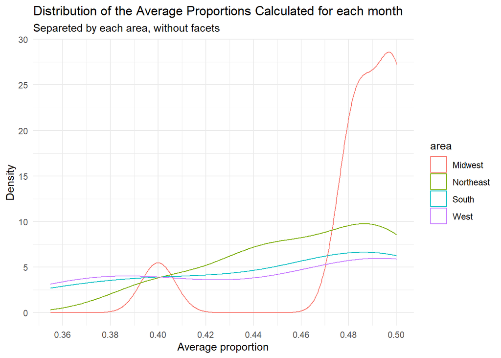

```r
ggplot(data = temp_gg4 , mapping = aes(x = avg_prop, color = area)) +
 geom_density() +
 scale_y_continuous(breaks = scales::pretty_breaks(n = 6)) +
  scale_x_continuous(breaks = scales::pretty_breaks(n = 6)) +
  labs(
        x= "Average proportion",
    y = "Density",
    title = "Distribution of the Average Proportions Calculated for each month",
    subtitle = "Separeted by each area, without facets"
  ) +
  theme_minimal()
```

```r
#ggsave("Distribution of the Average Proportions without facets.png")
```

**Explanation:** same plot but without facets. We can see now that in Northeast Trump has more support than the South and West.

- Merging the `polls_prop` and `merged_covid_wiki` data-set.
- Calculating the sum of cases and deaths for each record:

```r
results_polls_corona <- polls_prop %>%
  left_join(merged_covid_wiki) %>%
  filter(!is.na(num_cases)) %>%
  mutate(cases_deaths = num_deaths + num_cases)
results_polls_corona
```

```
## # A tibble: 16,814 x 10
## # Groups:   Date, full_name [8,407]
##    Date       full_name winner_name     n     p short_name num_cases num_deaths
##    <date>     <chr>     <chr>       <int> <dbl> <chr>          <dbl>      <dbl>
##  1 2020-01-21 Texas     Not Trump       7   0.5 TX                 0          0
##  2 2020-01-21 Texas     Trump           7   0.5 TX                 0          0
##  3 2020-01-24 Arizona   Not Trump       1   0.5 AZ                 0          0
##  4 2020-01-24 Arizona   Trump           1   0.5 AZ                 0          0
##  5 2020-01-24 Texas     Not Trump       7   0.5 TX                 0          0
##  6 2020-01-24 Texas     Trump           7   0.5 TX                 0          0
##  7 2020-01-25 Texas     Not Trump       7   0.5 TX                 0          0
##  8 2020-01-25 Texas     Trump           7   0.5 TX                 0          0
##  9 2020-01-26 Texas     Not Trump       7   0.5 TX                 0          0
## 10 2020-01-26 Texas     Trump           7   0.5 TX                 0          0
## # ... with 16,804 more rows, and 2 more variables: area <chr>,
## #   cases_deaths <dbl>
```

### Build the first model:

#### Plot 8:

- We built a linear model as the proportion of Trumps wins in each pair (date, state) is the explanatory variable, and the sum of deaths and cases for this pair of (date, state) represents the response variable.

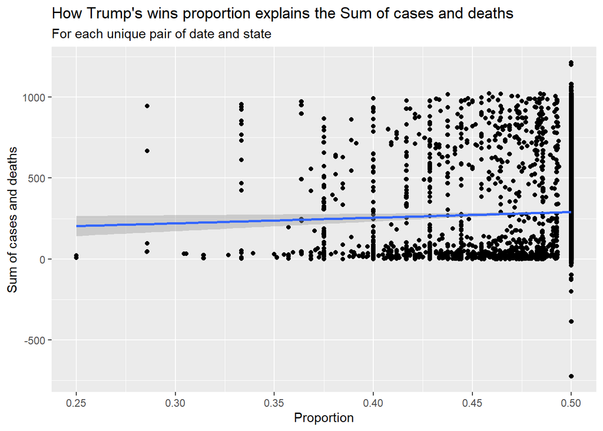

```r
ggplot(results_polls_corona %>% filter(winner_name=="Trump"), aes(x = p, y = cases_deaths)) +
  geom_point() +
  geom_jitter(alpha = 0.5) +
  geom_smooth(method = "lm") +
  labs(
    x = "Proportion",
    y = "Sum of cases and deaths",
    title = "How Trump's wins proportion explains the Sum of cases and deaths",
    subtitle = "For each unique pair of date and state"
  )
```

```r
#ggsave("How Trump's wins proportion explains the Sum of cases and deaths.png")
```

### Plot 9:

Same as the last plot, but here the response variable in log function.

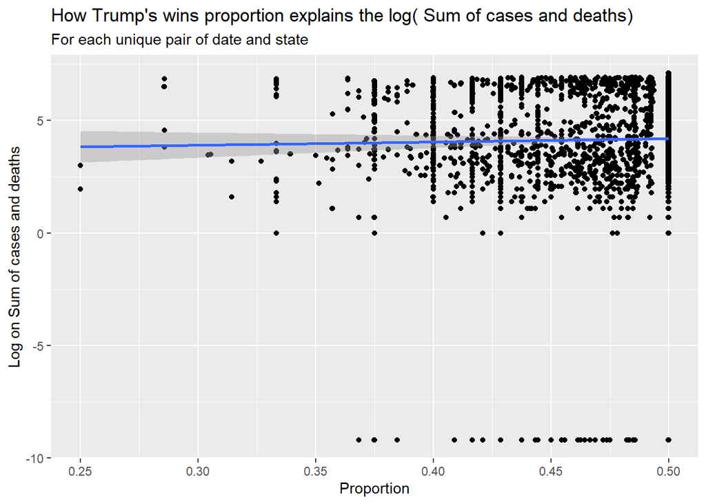

```r
ggplot(results_polls_corona %>% filter(winner_name=="Trump"), aes(x = p, y = log(num_deaths + num_cases+0.0001))) +
  geom_point() +
  geom_jitter() +
  geom_smooth(method = "lm")+
  labs(
    x = "Proportion",
    y = "Log on Sum of cases and deaths",
    title = "How Trump's wins proportion explains the log( Sum of cases and deaths)",
    subtitle = "For each unique pair of date and state"
  )
```

```r
#ggsave("How Trump's wins proportion explains the log( Sum of cases and deaths).png")
```

- We can see that the Log scale doesn’t help to see any new behavior.
- It’s helpful when we have right long tail.

let’s see how the Residuals look:

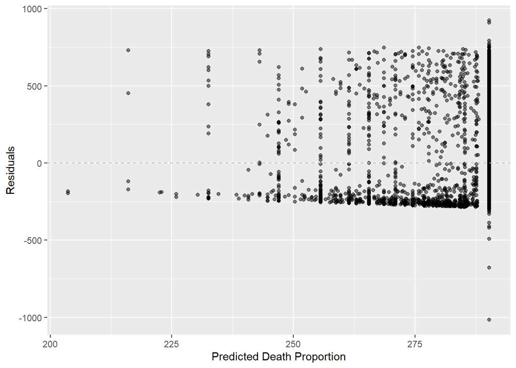

```r
polls_corona_trump <- results_polls_corona %>% filter(winner_name=="Trump")
polls_corona_fit <- linear_reg() %>%
  set_engine("lm") %>%
  fit(cases_deaths ~p , data = polls_corona_trump)
polls_corona_fit_aug <- augment(polls_corona_fit$fit)

ggplot(polls_corona_fit_aug, mapping = aes(x = .fitted, y = .resid)) +
  geom_point(alpha = 0.5) +
  geom_hline(yintercept = 0, color = "gray", lty = "dashed") +
  labs(x = "Predicted Death Proportion", y = "Residuals")
```

```r
#ggsave("first_model_residuals.png")
```

```r
R_sq<- glance(polls_corona_fit)$r.squared
cor <- cor(polls_corona_trump$p, polls_corona_trump$cases_deaths,
                    method = "pearson")
c("R Squared" = R_sq, "Correlation" = cor)
```

```
##    R Squared  Correlation
## 0.0008459393 0.0290850362
```

Really low values, the model don’t explain good the variability and the variables are even not correlated.

## Exploration 2:

- In this part we will explore data-sets of the elections results in 2016 and 2020.
- Also we will use a data-set that contains information about the population for each State.
- We would check if the changes in the public support in Trump between 2016 and 2020 elections (separated for each state) can explain the proportion of cases and deaths for each state .

```r
president_state <- read_csv(here::here("data", "president_state.csv"))
president_country_candidate <- read_csv(here::here("data", "president_county_candidate.csv")) %>%
  rename(full_name = state)
elections_2016 <- read_csv(here::here("data", "2016_elections.csv"))
```

- Let’s start with 2020:
- First - data tidying.

```r
president_state <- president_state %>% rename(full_name = state) %>%
   left_join(countries) %>%
  mutate(short_name = case_when(
    full_name=="District of Columbia" ~ "DC",
    full_name=="United States" ~ "US",
    T ~ short_name
  ))
president_state
```

```
## # A tibble: 52 x 4
##    full_name            total_votes short_name area
##    <chr>                      <dbl> <chr>      <chr>
##  1 Delaware                  504010 DE         Northeast
##  2 District of Columbia      344356 DC         Northeast
##  3 Florida                 11067456 FL         South
##  4 Georgia                  4997716 GA         South
##  5 Hawaii                    574469 HI         West
##  6 Idaho                     868106 ID         West
##  7 Illinois                 6038843 IL         Midwest
##  8 Indiana                  3033198 IN         Midwest
##  9 Iowa                     1690871 IA         Midwest
## 10 Kansas                   1375304 KS         Midwest
## # ... with 42 more rows
```

- calculate the proportion of votes to Trump for each state’s `short_name`

```r
(elections_2020_prop<-president_country_candidate %>%
  mutate(candidate = if_else(candidate=="Donald Trump", "Trump", "Not Trump")) %>%
  group_by(full_name, candidate )%>%
  summarise(state_candidate_votes = sum(total_votes, na.rm = T), .groups = "drop") %>%
  group_by(full_name) %>%
  mutate(prop2020 = state_candidate_votes/sum(state_candidate_votes)) %>%
  left_join(president_state , by= "full_name") %>%
  ungroup() %>%
  select(short_name,candidate, prop2020 ) %>%
  group_by(short_name, candidate))
```

```
## # A tibble: 102 x 3
## # Groups:   short_name, candidate [102]
##    short_name candidate prop2020
##    <chr>      <chr>        <dbl>
##  1 AL         Not Trump    0.380
##  2 AL         Trump        0.620
##  3 AK         Not Trump    0.515
##  4 AK         Trump        0.485
##  5 AZ         Not Trump    0.509
##  6 AZ         Trump        0.491
##  7 AR         Not Trump    0.376
##  8 AR         Trump        0.624
##  9 CA         Not Trump    0.657
## 10 CA         Trump        0.343
## # ... with 92 more rows
```

- same kind of calculation with the 2016 election’s data-set:

```r
elections_2016_prop <- elections_2016 %>%
  filter(!is.na(`LAST NAME`)) %>%
  mutate(`LAST NAME` = if_else(`LAST NAME`=="Trump","Trump", "Not Trump")) %>%
  select(`STATE ABBREVIATION`, `LAST NAME`, `GENERAL %`)
elections_2016_prop$`GENERAL %` <- str_replace(elections_2016_prop$`GENERAL %`, '%', '')
elections_2016_prop$`GENERAL %` <- as.numeric(elections_2016_prop$`GENERAL %`)
(elections_2016_prop <- elections_2016_prop %>%
  group_by(`STATE ABBREVIATION`, `LAST NAME`) %>%
  summarise(prop = sum(`GENERAL %`, na.rm = T), .groups = "drop") %>%
  rename(short_name = `STATE ABBREVIATION`,
         candidate = `LAST NAME`,
         prop2016 = prop) %>%
  mutate(prop2016 = prop2016/100) %>%
  ungroup())
```

```
## # A tibble: 102 x 3
##    short_name candidate prop2016
##    <chr>      <chr>        <dbl>
##  1 AK         Not Trump    0.487
##  2 AK         Trump        0.513
##  3 AL         Not Trump    0.379
##  4 AL         Trump        0.621
##  5 AR         Not Trump    0.394
##  6 AR         Trump        0.606
##  7 AZ         Not Trump    0.513
##  8 AZ         Trump        0.487
##  9 CA         Not Trump    0.684
## 10 CA         Trump        0.316
## # ... with 92 more rows
```

- Combining the data-sets of 2016 and 2020:

```r
(unite_elections <- elections_2020_prop %>%
  left_join(elections_2016_prop))
```

```
## # A tibble: 102 x 4
## # Groups:   short_name, candidate [102]
##    short_name candidate prop2020 prop2016
##    <chr>      <chr>        <dbl>    <dbl>
##  1 AL         Not Trump    0.380    0.379
##  2 AL         Trump        0.620    0.621
##  3 AK         Not Trump    0.515    0.487
##  4 AK         Trump        0.485    0.513
##  5 AZ         Not Trump    0.509    0.513
##  6 AZ         Trump        0.491    0.487
##  7 AR         Not Trump    0.376    0.394
##  8 AR         Trump        0.624    0.606
##  9 CA         Not Trump    0.657    0.684
## 10 CA         Trump        0.343    0.316
## # ... with 92 more rows
```

- Conversion of the proportions into percentage.
- Calculation of the difference between the percentage of support in trump between 2016 and 2020 elections.
- That is a kind of normalization to check if the corona changes the “normal voters behavior” (Probably not only the virus did so…)

```r
unite_elections<- unite_elections %>%
  mutate(prop2020 = prop2020*100,
         prop2016 = prop2016*100,
         change_2016_to_2020 = prop2020-prop2016)
```

distribution of `change_2016_to_2020` separated to the 4 areas:

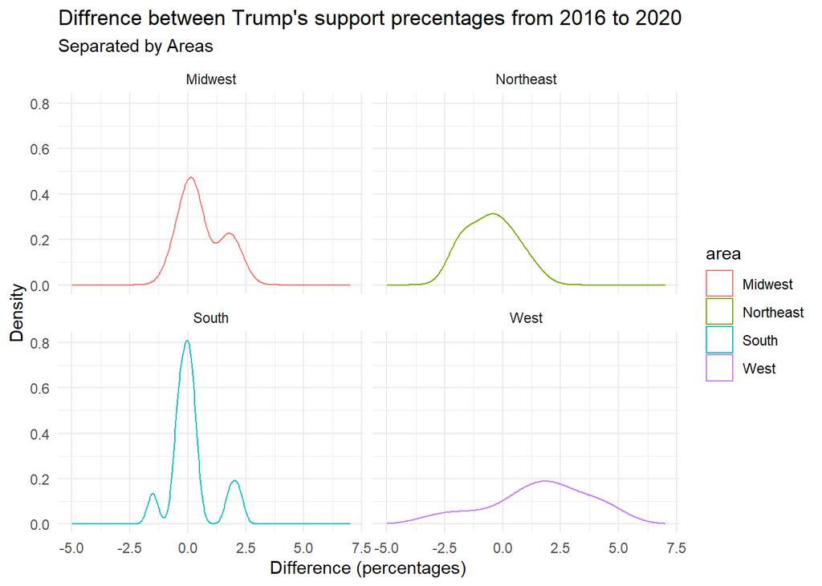

```r
ggplot(unite_elections %>%filter(candidate=="Trump") %>% left_join(countries), mapping = aes(x= change_2016_to_2020, color = area)) +
  geom_density() +
  scale_x_continuous(breaks = scales::pretty_breaks(n = 12)) +
  facet_wrap(~ area) +
  xlim(-5,7) +
  labs(
    title = "Diffrence between Trump's support precentages from 2016 to 2020",
    subtitle = "Separated by Areas",
    y = "Density",
    x = "Difference (percentages)"
  ) +
  theme_minimal()
```

```r
#ggsave("Diffrence between Trump's support precentages from 2016 to 2020.png")
```

**Explanation:** An interesting result is that in South’s countries the support percentage in Trump did not really changed. But people from states in the West changed their minds about Trump. Soon we will see if those changes can explain the corona deaths and cases.

- Tidying data of population (for each State):

```r
sum_cases_deaths <- merged_covid_wiki %>%
  group_by(short_name, full_name) %>%
  summarise(sum_deaths = sum(num_deaths, na.rm = T),
            sum_cases = sum(num_cases, na.rm = T))
population <- read_csv(here::here("data", "nst-est2019-01.csv"))
```

```r
population <-population %>%
  rename(full_name = `table with row headers in column A and column headers in rows 3 through 4. (leading dots indicate sub-parts)`,
         population = X13) %>%
  tail(58)
population$full_name <- str_replace(population$full_name, '.', '')
population<- population %>%
  left_join(countries) %>%
  mutate(short_name = if_else(full_name=="District of Columbia","DC", short_name )) %>%
  head(51) %>%
  select(full_name, population)
population
```

```
## # A tibble: 51 x 2
##    full_name            population
##    <chr>                     <dbl>
##  1 Alabama                 4903185
##  2 Alaska                   731545
##  3 Arizona                 7278717
##  4 Arkansas                3017804
##  5 California             39512223
##  6 Colorado                5758736
##  7 Connecticut             3565287
##  8 Delaware                 973764
##  9 District of Columbia     705749
## 10 Florida                21477737
## # ... with 41 more rows
```

### Plot 10:

1. Take the 8 states with the biggest turnout.
2. Among these state, we presented for each one the percentage of votes, Separated by votes for Trump and votes for other candidates.

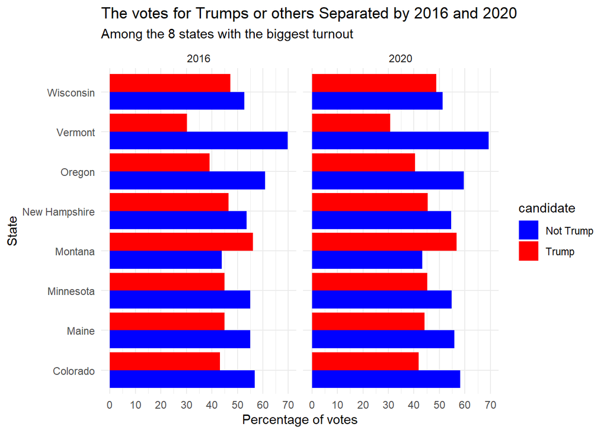

```r
big_turnout_countries <- population %>%
  left_join(president_state) %>%
  mutate(Turnout = (total_votes/population)*100) %>%
  arrange(desc(Turnout)) %>%
  head(8)%>%
  select(full_name, short_name, Turnout) %>%
  left_join(unite_elections, by = "short_name") %>%
  pivot_longer(c("prop2020", "prop2016"), names_to = "elections_year", values_to = "trump_ornot_p") %>%
  mutate(elections_year = if_else(elections_year=="prop2020", "2020", "2016"))
ggplot(data = big_turnout_countries, mapping = aes(x = factor(full_name), y = trump_ornot_p, fill = candidate))  +
  geom_bar(stat = "identity", position = "dodge") +
  facet_wrap(~ factor(elections_year)) +
  coord_flip() +
  scale_y_continuous(breaks = scales::pretty_breaks(n = 6)) +
  scale_fill_manual(values = c("blue", "red")) +
  labs(
    x = "State",
    y = "Percentage of votes",
    title = "The votes for Trumps or others Separated by 2016 and 2020",
    subtitle = "Among the 8 states with the biggest turnout"
  ) +
  theme_minimal()
```

```r
#ggsave("The votes for Trump or others Separated by 2016 and 2020.png")
```

**Explanation:** We does not see significant changes in Trump’s support in those states.

- We calculated here the proportion of death people and cases in each State’s population.
- We calculated new variable called `damage` that equals to 10*`death_prop` + `cases_prop`.

```r
results_of_covid <- population %>%
  left_join(sum_cases_deaths) %>%
  mutate(death_prop = sum_deaths/population,
         cases_prop = sum_cases/population,
         damage = 10*death_prop + cases_prop)
results_of_covid
```

```
## # A tibble: 51 x 8
##    full_name    population short_name sum_deaths sum_cases death_prop cases_prop
##    <chr>             <dbl> <chr>           <dbl>     <dbl>      <dbl>      <dbl>
##  1 Alabama         4903185 AL               8830    128486   0.00180    0.0262
##  2 Alaska           731545 AK                362     67648   0.000495   0.0925
##  3 Arizona         7278717 AZ              17700    122594   0.00243    0.0168
##  4 Arkansas        3017804 AR               4639    125316   0.00154    0.0415
##  5 California     39512223 CA              61356     13290   0.00155    0.000336
##  6 Colorado        5758736 CO               6613    114148   0.00115    0.0198
##  7 Connecticut     3565287 CT               8246     85048   0.00231    0.0239
##  8 Delaware         973764 DE               1534    105821   0.00158    0.109
##  9 District of~     705749 DC               1136     49068   0.00161    0.0695
## 10 Florida        21477737 FL              36985     40486   0.00172    0.00189
## # ... with 41 more rows, and 1 more variable: damage <dbl>
```

### Plot 11:

- This plot is an attempt to answer our research question.
- We have found the 7 states that suffered the biggest `damage` and the 7 states that suffered the most little `damage`.
- for those countries we have calculated the same plots as **plot 10** .

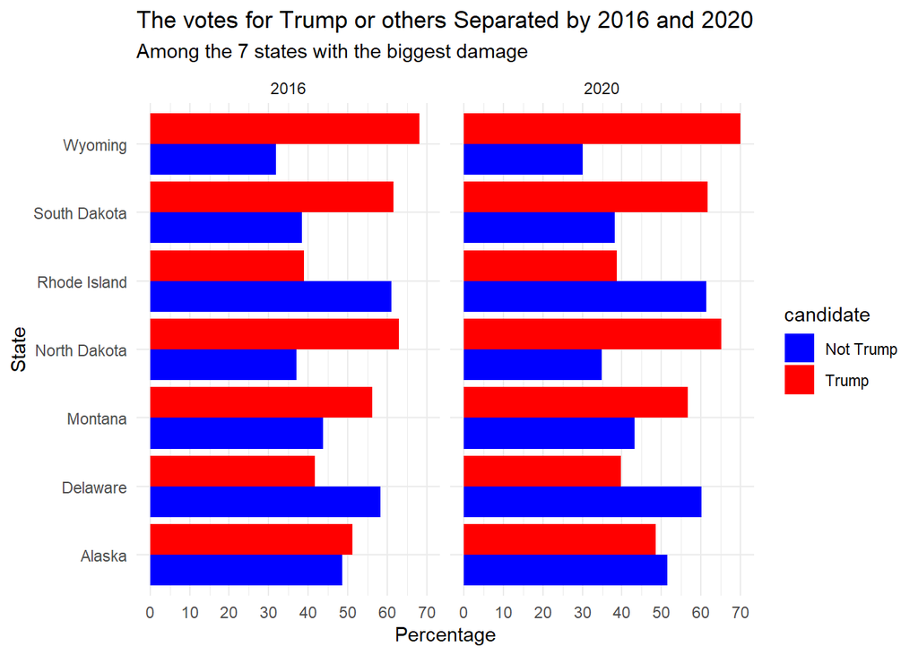

```r
hard_covid_states <- results_of_covid %>%
  arrange(desc(damage)) %>%
  head(7) %>%
  select(short_name)
easy_covid_states <- results_of_covid %>%
  arrange(damage) %>%
  head(7) %>%
  select(short_name)

ggplot(data = hard_covid_states %>%
  left_join(unite_elections, by = "short_name") %>%
  pivot_longer(c("prop2020", "prop2016"), names_to = "elections_year", values_to = "trump_ornot_p") %>%
  mutate(elections_year = if_else(elections_year=="prop2020", "2020", "2016")) %>%
    left_join(countries), mapping = aes(x = factor(full_name), y = trump_ornot_p, fill = candidate))  +
  geom_bar(stat = "identity", position = "dodge") +
  facet_wrap(~ factor(elections_year)) +
  coord_flip() +
  scale_y_continuous(breaks = scales::pretty_breaks(n = 6)) +
  scale_fill_manual(values = c("blue", "red")) +
  theme_minimal() +
  labs(title = "The votes for Trump or others Separated by 2016 and 2020",
       subtitle = "Among the 7 states with the biggest damage",
       x = "State",
       y = "Percentage"

  )
```

```r
#ggsave("The votes for Trump or others among states with biggest damage.png")
```

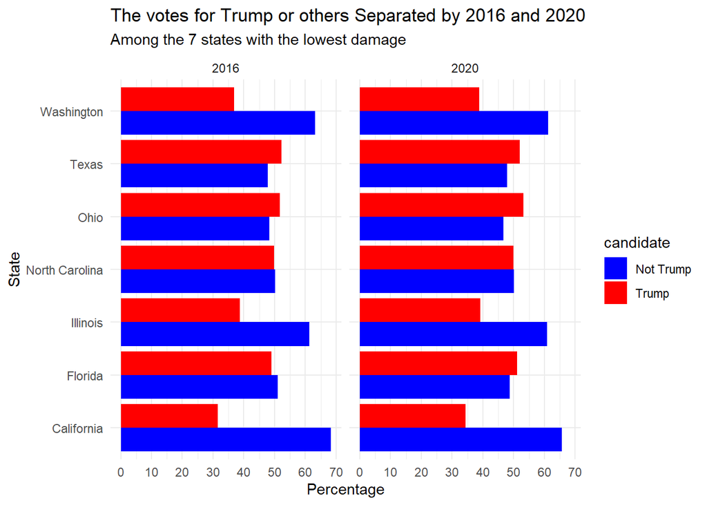

```r
ggplot(data = easy_covid_states %>%
  left_join(unite_elections, by = "short_name") %>%
  pivot_longer(c("prop2020", "prop2016"), names_to = "elections_year", values_to = "trump_ornot_p") %>%
  mutate(elections_year = if_else(elections_year=="prop2020", "2020", "2016")) %>%
    left_join(countries), mapping = aes(x = factor(full_name), y = trump_ornot_p, fill = candidate))  +
  geom_bar(stat = "identity", position = "dodge") +
  facet_wrap(~ factor(elections_year)) +
  coord_flip() +
  scale_y_continuous(breaks = scales::pretty_breaks(n = 6)) +
  scale_fill_manual(values = c("blue", "red"))+
  theme_minimal() +
  labs(title = "The votes for Trump or others Separated by 2016 and 2020",
       subtitle = "Among the 7 states with the lowest damage",
       x = "State",
       y = "Percentage"

  )
```

```r
#ggsave("The votes for Trump or others among states with lowest damage.png")
```

**Explanation:**

### The Second Model:

- First we combined `results_of_covid` and `unite_elections` to one data-set.

```r
(unite_results <- unite_elections %>%
  left_join(results_of_covid) %>%
    filter(candidate=="Trump") )
```

```
## # A tibble: 51 x 12
## # Groups:   short_name, candidate [51]
##    short_name candidate prop2020 prop2016 change_2016_to_2~ full_name population
##    <chr>      <chr>        <dbl>    <dbl>             <dbl> <chr>          <dbl>
##  1 AL         Trump        62.0     62.1            -0.0490 Alabama      4903185
##  2 AK         Trump        48.5     51.3            -2.76   Alaska        731545
##  3 AZ         Trump        49.1     48.7             0.386  Arizona      7278717
##  4 AR         Trump        62.4     60.6             1.83   Arkansas     3017804
##  5 CA         Trump        34.3     31.6             2.71   Californ~   39512223
##  6 CO         Trump        41.9     43.2            -1.35   Colorado     5758736
##  7 CT         Trump        39.2     40.9            -1.72   Connecti~    3565287
##  8 DE         Trump        39.8     41.7            -1.91   Delaware      973764
##  9 DC         Trump         5.40     4.09            1.31   District~     705749
## 10 FL         Trump        51.2     49.0             2.20   Florida     21477737
## # ... with 41 more rows, and 5 more variables: sum_deaths <dbl>,
## #   sum_cases <dbl>, death_prop <dbl>, cases_prop <dbl>, damage <dbl>
```

- The explanatory variable is the difference of support percentage in Trump from 2016 to 2020 in each state.
- The response variable is the proportion of deaths in the population of each country.

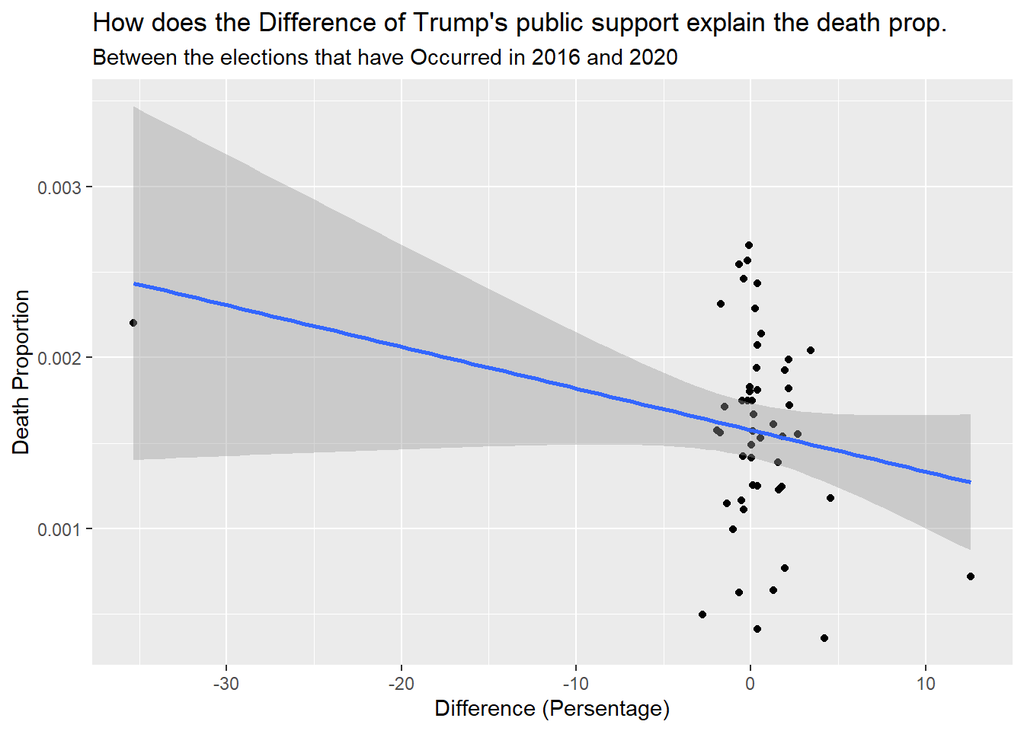

```r
ggplot(unite_results, aes(x = change_2016_to_2020, y = death_prop)) +
  geom_point() +
  geom_jitter() +
  geom_smooth(method = "lm")  +
  labs(x = "Difference (Persentage)",
       y = "Death Proportion",
       title = "How does the Difference of Trump's public support explain the death prop.",
       subtitle = "Between the elections that have Occurred in 2016 and 2020")
```

```r
#ggsave("How does the Difference of Trump's public support explain the death.png")
```

**Explanation:**

- It seems like the explanatory variable `change_2016_to_2020` does not explain the response variable `death_prop`.
- In the first impression the points seems to have a random behavior.

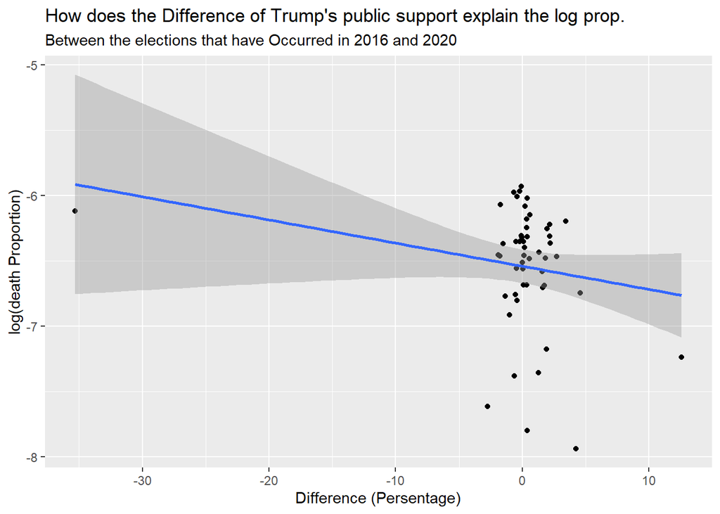

```r
ggplot(unite_results, aes(x = change_2016_to_2020, y = log(death_prop))) +
  geom_point() +
  geom_jitter() +
  geom_smooth(method = "lm")  +
  labs(
    x = "Difference (Persentage)",
       y = "log(death Proportion)",
       title = "How does the Difference of Trump's public support explain the log prop.",
       subtitle = "Between the elections that have Occurred in 2016 and 2020")
```

```r
#ggsave("How does the Difference of Trump's public support explain the log prop.png")
```

**Explanation:** We can see that the Log scale doesn’t help to see any new behavior.

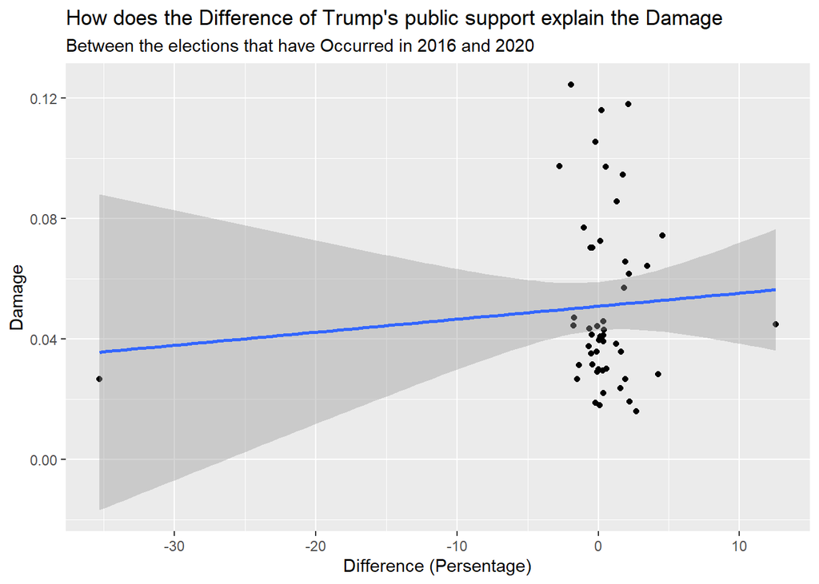

```r
ggplot(unite_results, aes(x = change_2016_to_2020, y = damage)) +
  geom_point() +
  geom_jitter() +
  geom_smooth(method = "lm")  +
  labs(
    x = "Difference (Persentage)",
       y = "Damage",
       title = "How does the Difference of Trump's public support explain the Damage",
       subtitle = "Between the elections that have Occurred in 2016 and 2020")
```

```r
#ggsave("How does the Difference of Trump's public support explain the Damage.png")
```

**Explanation:** Relatively similar results are obtained with `damage` as the response variable.

Let’s look at the residuals:

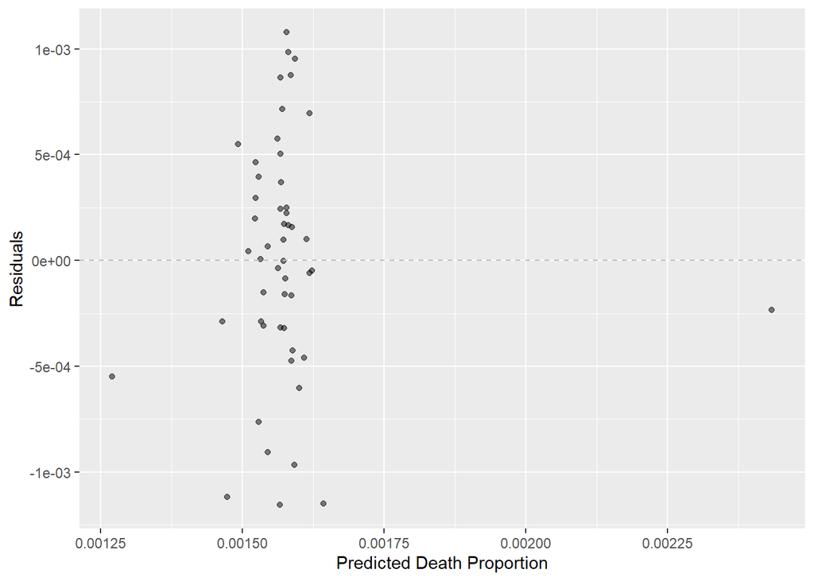

```r
elections_deaths_fit <- linear_reg() %>%
  set_engine("lm") %>%
  fit(death_prop ~ change_2016_to_2020, data = unite_results)
elections_deaths_fit_aug <- augment(elections_deaths_fit$fit)

ggplot(elections_deaths_fit_aug, mapping = aes(x = .fitted, y = .resid)) +
  geom_point(alpha = 0.5) +
  geom_hline(yintercept = 0, color = "gray", lty = "dashed") +
  labs(x = "Predicted Death Proportion", y = "Residuals")
```

```r
#ggsave("Residuals model 2.png")
```

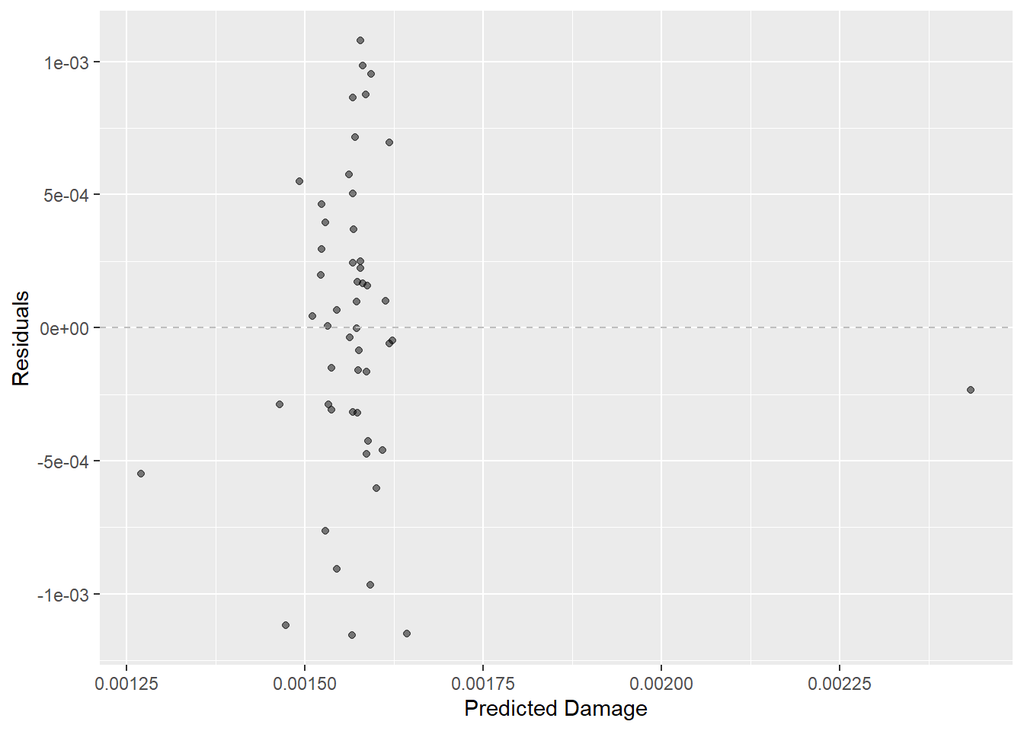

```r
elections_damage_fit <- linear_reg() %>%
  set_engine("lm") %>%
  fit(damage ~ change_2016_to_2020, data = unite_results)
elections_damage_fit_aug <- augment(elections_deaths_fit$fit)

ggplot(elections_damage_fit_aug, mapping = aes(x = .fitted, y = .resid)) +
  geom_point(alpha = 0.5) +
  geom_hline(yintercept = 0, color = "gray", lty = "dashed") +
  labs(x = "Predicted Damage", y = "Residuals")
```

```r
#ggsave("danmage residuals model 2.png")
```

- Residuals distributed nearly randomly around 0.
- With no visible pattern along the x or y axes.
- the problem is not the model selection.
- So probably the changes in Donald Trump’s support in between 2016 and 2020 elections can’t explain corona’s cases and deaths.
- let’s calculated R Squared and pearson correlation:

```r
R_sq<- glance(elections_deaths_fit)$r.squared
cor <- cor(unite_results$change_2016_to_2020, unite_results$death_prop,
                    method = "pearson")
c("R Squared" = R_sq, "Correlation" = cor)
```

```
##   R Squared Correlation
##  0.05502658 -0.23457744
```

- R squared is the percentage of variability in the response variable explained by the regression model.
- In this model the R squared and correlation are better than the last model, but still those values are low. The model does not explain most of the variability in the response variable.
- the feature and the response variable are not correlated.
- After seeing the results of the two model: our conclusion is that the explanatory variables we chose can’t explain corona’s cases and deaths.
- So we would carefully define that the changes in US public support (separated by countries) in Donald Trump don’t explain the extent of the damage from covid-19 (that those countries have experienced).